# Dissertation 3.1 Analysis (Crossover Microbiologist)

In this script, I’m processing data from an experiment where participants had to categorize amoeba with three different features. In the first block (LB1), only one dimension (determined by condition) was relevant; in subsequent blocks, exceptions were introduced that made all three dimensions relevant. Participants “uncovered” parts of the stimulus with their cursor, and their cursor position was recorded as a proxy for eye-tracking data.

I’ll start by loading in my libraries and importing the data.

```r
library(easystats)
```

```r
df_full <- read_csv('combined_pilot_data.csv')
coords <- read_csv("coords.csv") # This has the mouse-tracking data for each subject.
```

# Data wrangling

## Coordinate data

I need to figure out which dimensions participants were looking at and how much they were looking at each dimension during a given trial.

```r
df_coords <- coords %>% mutate(block = case_when( # Add learning block column
  grepl("0.0-9.0", internal_node_id) ~ "LB1",
  grepl("0.0-10", internal_node_id) ~ "LB1",
  grepl("0.0-12.0", internal_node_id) ~"LB2",
  grepl("0.0-14.0", internal_node_id) ~"LB3",
  grepl("0.0-16.0", internal_node_id) ~"NF1",
  grepl("0.0-18.0", internal_node_id) ~"NF2",
  TRUE ~ "Other")) %>%
  group_by(run_id) %>%
  mutate(xmin = min(x),
         xmax = max(x),
         ymin = min(y),
         ymax = max(y)) %>%
  mutate(xmid = (xmin + xmax)/2,
         ymid = mean(ymin + ymax)/2) %>%
  mutate(dim = case_when( # Plot points as circles with radius 1/4 the width of x
    x < (sqrt(((xmax - xmin)/4)^2 - (y - ((ymid+ymin)/2))^2) + xmid) & y < (sqrt(((xmax - xmin)/4)^2 - (x - xmid)^2) + (ymid+ymin)/2) ~ "D1",
    x < (sqrt(((xmax - xmin)/4)^2 - (y - (ymid + (ymax-ymin)/8))^2) + (xmid+xmin)/2) & y < (sqrt(((xmax - xmin)/4)^2 - (x - (xmid+xmin)/2)^2) + (ymid + (ymax-ymin)/8)) ~ "D2",
    x < (sqrt(((xmax - xmin)/4)^2 - (y - (ymid + (ymax-ymin)/8))^2) + (xmax+xmid)/2) & y < (sqrt(((xmax - xmin)/4)^2 - (x - (xmax+xmid)/2)^2) + (ymid + (ymax-ymin)/8)) ~ "D3",
    TRUE ~ "Other"
  ))
# Okay now get proportion per trial; start with fixation duration
df_coords <- df_coords %>%
  filter(block != "Other") %>%
  arrange(run_id, time) %>%
  group_by(run_id, trial_index) %>%
  mutate(trial_dur = last(time) - first(time)) %>%
  ungroup() %>%
  arrange(run_id, trial_index, time) %>%
  group_by(run_id, trial_index) %>%
  mutate(duration = lead(time, default = last(time)) - time) %>%
  replace_na(list(duration = 0)) %>%
  ungroup()

# Now sum for each dimension and get proportion
df_coords <- df_coords %>% ungroup() %>%
  group_by(run_id, trial_index, dim) %>%
  mutate(dim_dur = sum(duration)) %>%
  mutate(dim_prop = dim_dur/trial_dur) %>%
  ungroup() %>%
  group_by(run_id, trial_index, block, dim) %>%
  summarize(mean_prop = mean(dim_prop))
# And I want a wider format with no NAs before I merge:
df_coords <- df_coords %>%
  pivot_wider(names_from = dim, values_from = mean_prop)

df_coords <- df_coords %>%
  mutate(across(c(D1, D2, D3), ~ifelse(is.na(.), 0, .)))
```

## Accuracy data

```r
df_full <- df_full %>% mutate(block = case_when(
  grepl("0.0-9.0", internal_node_id) ~ "LB1",
  grepl("0.0-10", internal_node_id) ~ "LB1",
  grepl("0.0-12.0", internal_node_id) ~"LB2",
  grepl("0.0-14.0", internal_node_id) ~"LB3",
  grepl("0.0-16.0", internal_node_id) ~"NF1",
  grepl("0.0-18.0", internal_node_id) ~"NF2",
  TRUE ~ "Other")) %>%
  filter(block == "LB1" | block == "LB2" | block == "LB3" | block == "NF1") %>%
  filter(task == "response") %>%
  dplyr::select(run_id, condition, block, trial_index, internal_node_id, time_elapsed, rt, stimulus, response, correct_response, correct, block) %>%
  filter(response != "null") %>%
  mutate(correct = recode(correct, 'true' = 1, 'false' = 0, 'TRUE' = 1, 'FALSE' = 0)) %>%
  group_by(run_id, block) %>%
  arrange(trial_index) %>%
  mutate(count = row_number())
df_full$correct = as.numeric(df_full$correct)
```

## Combine!

```r
big_df <- right_join(df_full, df_coords, by = c("run_id", "block", "trial_index")) # got rid of trial_index
big_df["condition"] <- lapply(big_df["condition"], as.factor)

# Add "type" column, which changes depending on condition
big_df <- big_df %>%
  mutate(rD = case_when(condition == 1 ~ D1,
                        condition == 2 ~ D2,
                        condition == 3 ~ D3,
                        TRUE ~ 0),
         irD1 = case_when(condition == 1 ~ D2,
                        condition == 2 ~ D3,
                        condition == 3 ~ D1,
                        TRUE ~ 0),
         irD2 = case_when(condition == 1 ~ D3,
                        condition == 2 ~ D1,
                        condition == 3 ~ D2,
                        TRUE ~ 0),
         type = case_when(condition == 1 & (stimulus == "img/100-i.png" |
                                              stimulus == "img/100-ii.png" |
                                              stimulus == "img/011-i.png" |
                                              stimulus == "img/011-ii.png") ~ 'exception',
                        condition == 2 & (stimulus == "img/010-i.png" |
                                            stimulus == "img/010-ii.png" |
                                            stimulus == "img/101-i.png" |
                                            stimulus == "img/101-ii.png") ~ 'exception',
                        condition == 3 & (stimulus == "img/001-i.png" |
                                            stimulus == "img/001-ii.png" |
                                            stimulus == "img/110-i.png" |
                                            stimulus == "img/110-ii.png") ~ 'exception',
                        TRUE ~ 'rule-follower'))
```

## Exclusions

```r
all_sub <- unique(big_df$run_id)

# Participants excluded for incomplete data (visual assessment):
incomplete_data = c(123, 130, 143, 147, 153, 157, 162, 167, 172,
                    176, 174, 177, 189, 191, 201, 206, 208,
                    210, 214, 224, 226, 232, 234, 239, 248)

# Exclusions based on accuracy (and calculation of per-block accuracy):
big_df <- big_df %>%
  filter(!(run_id %in% incomplete_data)) %>%
  arrange(run_id, block, trial_index) %>%
  group_by(run_id, block, type) %>%
  mutate(mean_acc = mean(correct, na.rm = TRUE))

incl_acc <- unique((big_df %>% filter(block == 'NF1' & mean_acc > .7))$run_id)

big_df <- big_df %>%
  filter((run_id %in% incl_acc))
```

# Analysis!

## Accuracy

Okay, I’m interested in a few separate findings. First is accuracy per block broken down by type

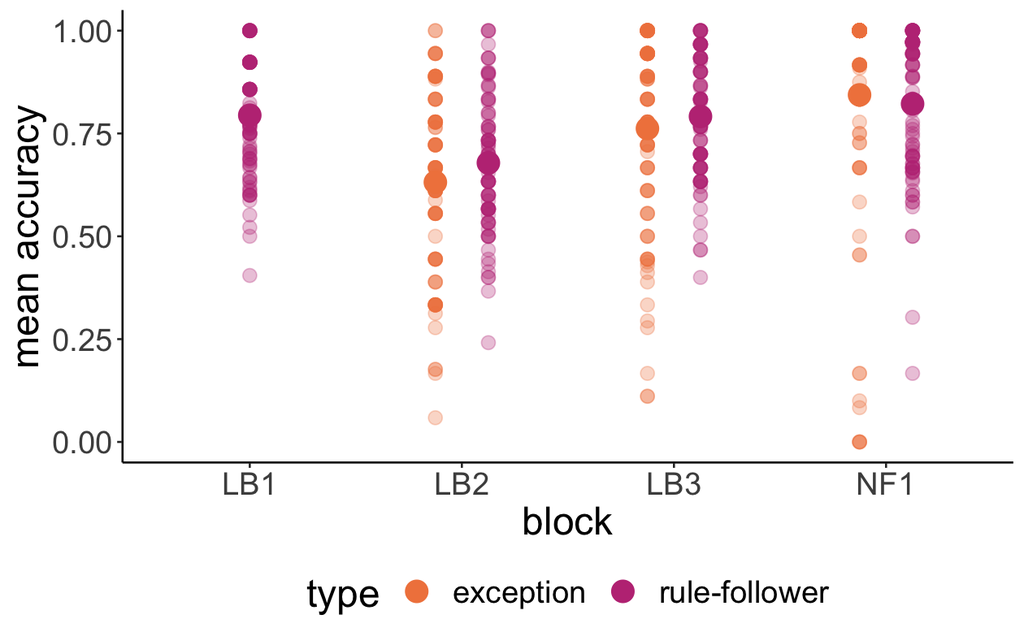

```r
summary_df <- big_df %>%
  ungroup() %>%
  group_by(run_id, block, type) %>%
  summarize(mean_acc = mean(correct, na.rm = TRUE))
colors <- c("exception" = "#f1844b", "rule-follower" = "#bf3984")

acc_plot <- ggplot() +
  geom_point(data = summary_df, aes(x=block, y=mean_acc, colour = type), size = 3, alpha = 0.3, position = position_dodge(width = .5)) +
  geom_point(data = summary_df %>% group_by(block, type) %>%
               dplyr::summarize(mean_acc2 = mean(mean_acc)),
             aes(x=block, y=mean_acc2, colour = type), size = 5, position = position_dodge(width = .5)) +
  theme_classic() +
  theme(legend.position = "bottom") +
  theme(text = element_text(size = 20)) +
  ylab("mean accuracy") +
  xlab("block") +
  scale_color_manual(values = colors)
plot(acc_plot)
ggsave('img/3_1_acc.png', width = 16, height = 10, units = 'cm')
```

```r
summary(tmp)
```

```
Call:
glm(formula = mean_acc ~ type, data = summary_df %>% filter(block ==
    "NF1"))

Deviance Residuals:
    Min       1Q   Median       3Q      Max
-0.8438  -0.1165   0.1209   0.1562   0.1780

Coefficients:
                  Estimate Std. Error t value Pr(>|t|)
(Intercept)        0.84380    0.02446  34.493   <2e-16 ***
typerule-follower -0.02183    0.03460  -0.631    0.529
---
Signif. codes:  0 ‘***’ 0.001 ‘**’ 0.01 ‘*’ 0.05 ‘.’ 0.1 ‘ ’ 1

(Dispersion parameter for gaussian family taken to be 0.05385789)

    Null deviance: 9.6082  on 179  degrees of freedom
Residual deviance: 9.5867  on 178  degrees of freedom
AIC: -11.046

Number of Fisher Scoring iterations: 2
```

## Entropy

First thing I want to show is how entropy is changing over time for rule-followers and exceptions in LB1, LB2, and LB3 (?)

| Parameter | CI | CI_low | CI_high |
| --- | --- | --- | --- |
| (Intercept) | 0.95 | 1.073912396 | 1.2601318527 |
| count | 0.95 | -0.003140778 | -0.0006203809 |
| typerule-follower | 0.95 | -0.056514839 | 0.0339472270 |
| count:typerule-follower | 0.95 | -0.001307671 | 0.0016896980 |

## Entropy and accuracy

```r
summary_long <- summary_long %>%
  ungroup() %>%
  pivot_wider(names_from = c(block),
              values_from = c(correct, rD, irD1, irD2, entropy, max_count),
              names_sep = "_")
```

[output not shown]

```r
summary(ent_acc_lb3)
```

```
Call:
glm(formula = eol_acc ~ entropy_LB3 * type, data = summary_long)

Deviance Residuals:
     Min        1Q    Median        3Q       Max
-0.54074  -0.09986   0.00798   0.10476   0.29429

Coefficients:
                               Estimate Std. Error t value Pr(>|t|)
(Intercept)                    0.669671   0.038322  17.475  < 2e-16 ***
entropy_LB3                    0.141878   0.032196   4.407 1.82e-05 ***
typerule-follower             -0.005627   0.055896  -0.101    0.920
entropy_LB3:typerule-follower  0.004445   0.047061   0.094    0.925
---
Signif. codes:  0 ‘***’ 0.001 ‘**’ 0.01 ‘*’ 0.05 ‘.’ 0.1 ‘ ’ 1

(Dispersion parameter for gaussian family taken to be 0.01702983)

    Null deviance: 3.6374  on 179  degrees of freedom
Residual deviance: 2.9973  on 176  degrees of freedom
AIC: -216.33

Number of Fisher Scoring iterations: 2
```